# Math 120 Week 03

Prof Miller

01 March, 2021

# Monday Feb 22

## Correlation

Last time: scatterplots. Main tool for looking at relationship between two variables in a dataset.

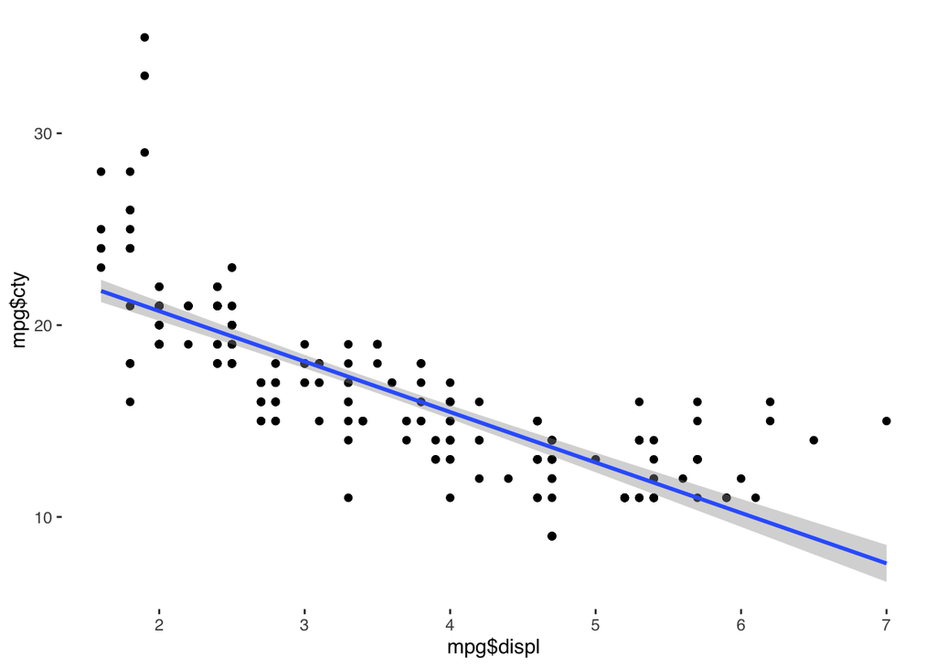

```r
qplot(mpg$displ, mpg$cty)+geom_smooth(method="lm")
```

```r
cor(mpg$displ, mpg$cty)
```

```
## [1] -0.798524
```

Observation: relationship! Mpg goes down when displ goes up!

Ex: cty vs hwy

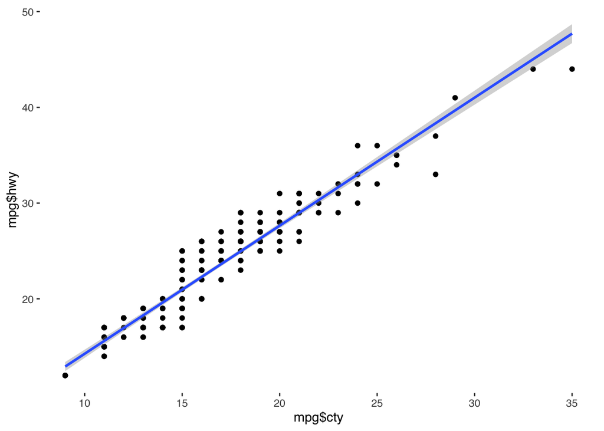

```r
qplot(mpg$cty, mpg$hwy)+geom_smooth(method="lm")
```

```r
cor(mpg$cty, mpg$hwy)
```

```
## [1] 0.9559159
```

Woah! Looks like cars that are more efficient in the city are also more efficient on the highway. Makes sense!

Ex: Iris data: sepal length vs width:

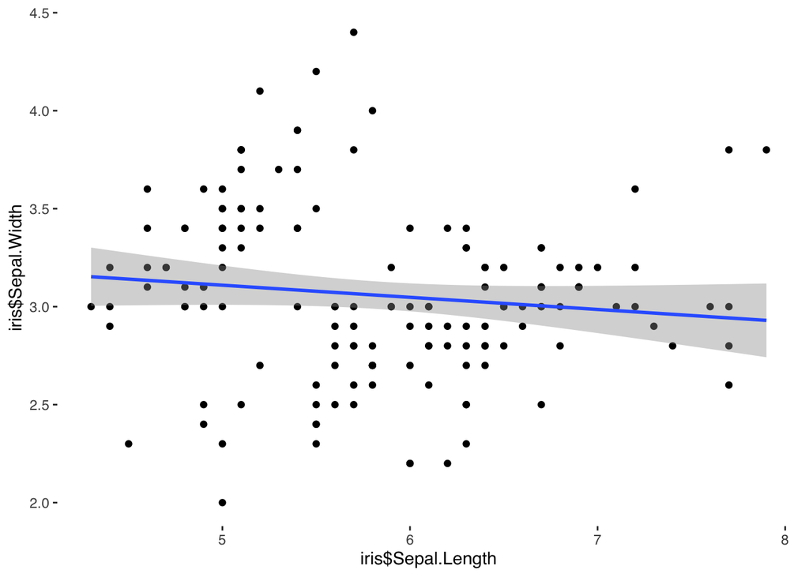

```r
qplot(iris$Sepal.Length, iris$Sepal.Width)+geom_smooth(method="lm")
```

```r
cor(iris$Sepal.Length, iris$Sepal.Width)
```

```
## [1] -0.1175698
```

Hmm, looks like a blob. Doesn’t seem that knowing one tells much about the other.

## Observations to make about scatterplot

3 key features:

## The linear correlation coefficient, r

Idea:

### Important properties of r

## Linear Regression

The line!!!

Goal: if there’s a linear relationship, what’s the equation of that line? What does it tell us? What can we use it for?

Lots of different names:

- best fit line
- regression line
- least squares line
- trend line
- etc etc

Imporant fact:

My favorite name for “the line”: Least Squares Line

Question: what makes it the “best”? Picture:

Answer: the least squares line is the one that …

# Wed Feb 24

IMPORTANT CONTEXT: The least squares line models y based upon x!!

This “order” matters! Be careful what you’re basing your precictions -upon-. That’s x!

The linear model is a line! All lines have same type of equation:

```
y = mx + b
```

where:

- m is the slope
- b y-int

Same for us. Use different letters/notation:

```
yhat = b0 + b1*x
```

where

- b0 is …
- b1 is …

If you can compute these, you know the equation! Fortunately, pretty easy!

## Computing eqn of least squares.

1. Find slope first:

Stories for this formula:

2. Find the intercept:

Fun fact: the best fit line ALWAYS touches the point …

From this, we have:

Practice Example: Suppose for a dataset, xbar = 1, ybar = 2, sx = 3, sy=4, r=1/2

# Friday Feb 26

## Interpreting the coefficients

Coefficients: slope and intercept.

Goal: study the relationship between x and y. The coeffs of the linear model tell us a lot about that relationship!

### Slope

From high school: deltay/delta x. If x changes by 1, then y changes by the slope.

Remember, yhat is our PREDICTION. So:

On the quiz, NEVER JUST SAY “X” OR “Y”! Describe IN CONTEXT!

Ex: In a sample of 50 men, the average height was 69.2" with stdev 3.1". The mean weight was 174 lbs with stdev 10.4 lbs. The correlation coefficient between height and weight is r=0.78.

Find the eqn for the linear model that predicts weight based upon height. Interpret the slope of line, in context.

Ex: We found the linear model for predicting petal width based on petal length:

```
yhat= -0.363 + 0.416x
```

Interpret the slope.

### Intercept

From HS: the intercept is the y-coord where x=0.

In lin reg:

Ex: Height and weight.

```
yhat = -7.096 + 2.617x
```

Interpet the intercept.

This is silly! In particular: extrapolation! Ie …

Ex: iris petals

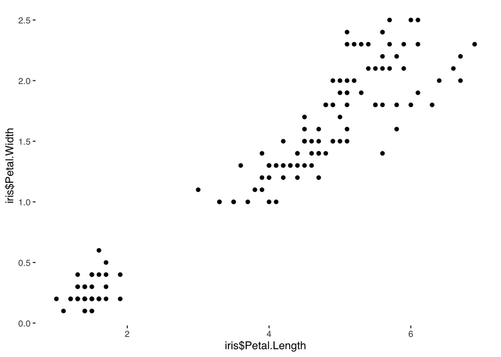

```
 yhat= -0.363 + 0.416x
```

```r
qplot(iris$Petal.Length, iris$Petal.Width)
```

Interpret the interce pt:  
Also extrapolation!

## Evaluating the model

Idea: we know how to construct and interpret the linear model. But, how good is it? How useful? Are the predictions it makes good or bad?

The correlation coefficient tells us something about how strong relationship is. But, what about the predictions it makes?

First: effects of outliers.

Example: iris data. Model: x=sepal length, y=sepal width.

Recall: r = -0.117. Blob!

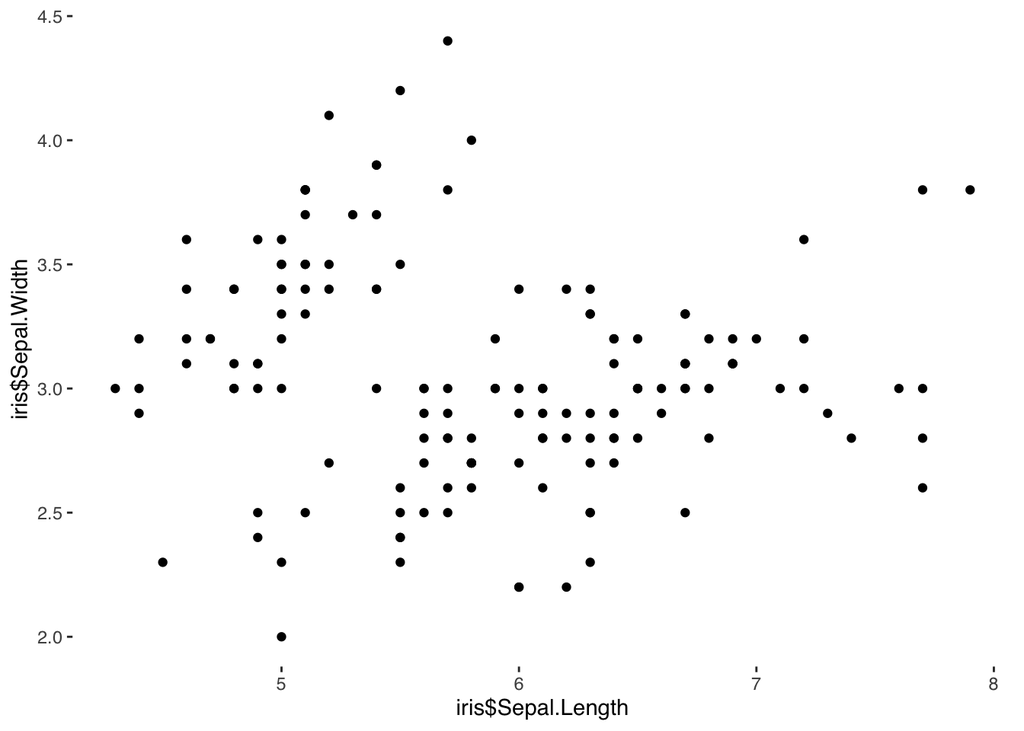

```r
qplot(iris$Sepal.Length, iris$Sepal.Width)
```

Add outlier: x=40, y=40